# ISGC

Marion Maisonobe

30/04/2021

## ISGC Congress

ISGC is an international conference of green chemistry held every two years in La Rochelle since 2013. In the frame of the NETCONF research project we focus on several editions of the conference in order to study its structure and dynamics. we are interested in communications, panels, topics, participants and their geographical origin. We consider studying conferences can bring many insights on emergent scientific communities, both regarding their organisation and dynamics.

## Topics

We first look at the topics associated to flash and oral communications given at the ISGC congress over time. We notice that Biomass conversion is the more popular topic. It attracted 80 communications at the 2019 edition. However, we notice that certain topics are not represented at every ISGC editions. It is notably the case of Biomass conversion which was not present at the 2017 edition. During the 2017 edition, it appears that Biomass conversion has been temporarily replaced by another category named Renewable carbon (see Table 1 below).

| ISGC topic | Number and % of oral and flash communications 2015 Nb | Number and % of oral and flash communications 2015 % | Number and % of oral and flash communications 2017 Nb | Number and % of oral and flash communications 2017 % | Number and % of oral and flash communications 2019 Nb | Number and % of oral and flash communications 2019 % | Number and % of oral and flash communications Total Nb | Number and % of oral and flash communications Total % |
| --- | --- | --- | --- | --- | --- | --- | --- | --- |
| Biomass conversion | 93 | 38.3 | 0 | 0.0 | 80 | 26.0 | 173 | 20.2 |
| Renewable carbon | 0 | 0.0 | 125 | 41.0 | 0 | 0.0 | 125 | 14.6 |
| Alternative solvents | 31 | 12.8 | 35 | 11.5 | 24 | 7.8 | 90 | 10.5 |
| Homogenous, heterogenous and biocatalysis | 0 | 0.0 | 0 | 0.0 | 68 | 22.1 | 68 | 7.9 |
| Polymers | 0 | 0.0 | 33 | 10.8 | 28 | 9.1 | 61 | 7.1 |
| Catalytic systems | 0 | 0.0 | 58 | 19.0 | 0 | 0.0 | 58 | 6.8 |
| Polymers and materials | 36 | 14.8 | 0 | 0.0 | 0 | 0.0 | 36 | 4.2 |
| Waste valorization | 0 | 0.0 | 0 | 0.0 | 34 | 11.0 | 34 | 4.0 |
| Alternative technologies | 0 | 0.0 | 0 | 0.0 | 24 | 7.8 | 24 | 2.8 |
| Atom-economy synthesis | 22 | 9.1 | 0 | 0.0 | 0 | 0.0 | 22 | 2.6 |
| Chemical valorization of wastes | 18 | 7.4 | 0 | 0.0 | 0 | 0.0 | 18 | 2.1 |
| Environnemental impact and life cycle assessment | 0 | 0.0 | 16 | 5.2 | 0 | 0.0 | 16 | 1.9 |
| Clean reactions | 0 | 0.0 | 0 | 0.0 | 16 | 5.2 | 16 | 1.9 |
| Eco-technology | 15 | 6.2 | 0 | 0.0 | 0 | 0.0 | 15 | 1.8 |
| Biotechnologies | 0 | 0.0 | 15 | 4.9 | 0 | 0.0 | 15 | 1.8 |
| Life cycle and environmental assessment | 0 | 0.0 | 0 | 0.0 | 12 | 3.9 | 12 | 1.4 |
| Mechanism | 0 | 0.0 | 11 | 3.6 | 0 | 0.0 | 11 | 1.3 |
| Industrial chemistry | 0 | 0.0 | 0 | 0.0 | 11 | 3.6 | 11 | 1.3 |
| Clean hydrogen production | 10 | 4.1 | 0 | 0.0 | 0 | 0.0 | 10 | 1.2 |
| Predictive method for green chemistry | 10 | 4.1 | 0 | 0.0 | 0 | 0.0 | 10 | 1.2 |
| Environmental and ethical assessments | 8 | 3.3 | 0 | 0.0 | 0 | 0.0 | 8 | 0.9 |
| Chemical engineering | 0 | 0.0 | 0 | 0.0 | 8 | 2.6 | 8 | 0.9 |
| Non-thermal activation methods | 0 | 0.0 | 7 | 2.3 | 0 | 0.0 | 7 | 0.8 |
| Networking and education | 0 | 0.0 | 3 | 1.0 | 3 | 1.0 | 6 | 0.7 |
| Smart use of fossil | 0 | 0.0 | 2 | 0.7 | 0 | 0.0 | 2 | 0.2 |
| Total | 243 | 100.0 | 305 | 100.0 | 308 | 100.0 | 856 | 100.0 |

According to François Jérôme, the main organiser of the ISGC conference, it is possible to associate certain similar topics so that we can better analyse trends in the popularity of ISGC topics over time. I refer to his suggestions to decide which topics can be grouped together on the basis of their similarity. Following this operation, we obtain 16 unique topics.

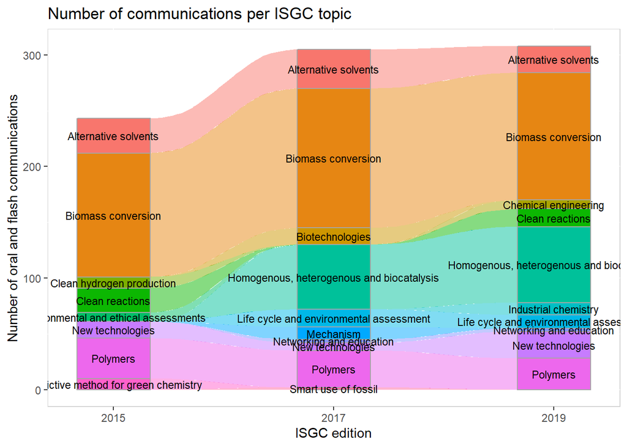

## Participation

There are different ways of approaching the conference participation. It can be analysed using registration data or though the lens of communications’ authors i.e. active participants. In the latter case, it is possible to filter the information to consider only the active participants who registered to the conference. Indeed, certain communications’ co-authors did not attend the conference.

In what follows, we consider the participation through the lens of all communications’ authors, whether they registered or not.

By counting all the speakers including industrials and keynote speakers over the 3 editions of the congress, we find a total of 3867 participants. Among them, 151 were represented at all editions, 3255 intervened to 1 edition only, (i.e. 84.17%), and 461 contributed to 2 editions.

If we limit ourselves to participants to oral communications and flash communications panels, we find a total of 2395 participants. Among them, 97 were represented at all editions, 2015 intervened to 1 edition only, (i.e. 84.13%), and 283 contributed to 2 editions.

Overall, there had been 219 oral and flash communications distinct panels: 64 in 2015, 78 in 2017, and 77 in 2019.

In chemistry, most communications are the result of a team work. At ISGC, there is an average of 4.13 authors per oral and flash communications.

## Networks of panels

In each of the graphs below, the grey dots denote a Congress panel, the blue dots denote participants who attended only one panel, and the red dots denote ‘multi-positional’ participants who attended more than one Congress panel. Finally, the intensity of the links refers to an inverse weighting that visually accentuates participation in panels with few participants.

Remember that we are counting potential participants here: in practice, some of these participants will not have come to the Congress.

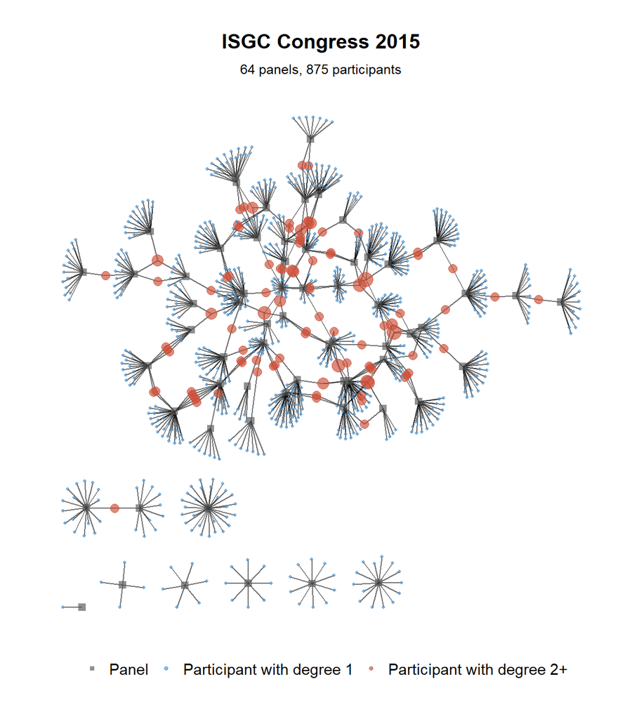

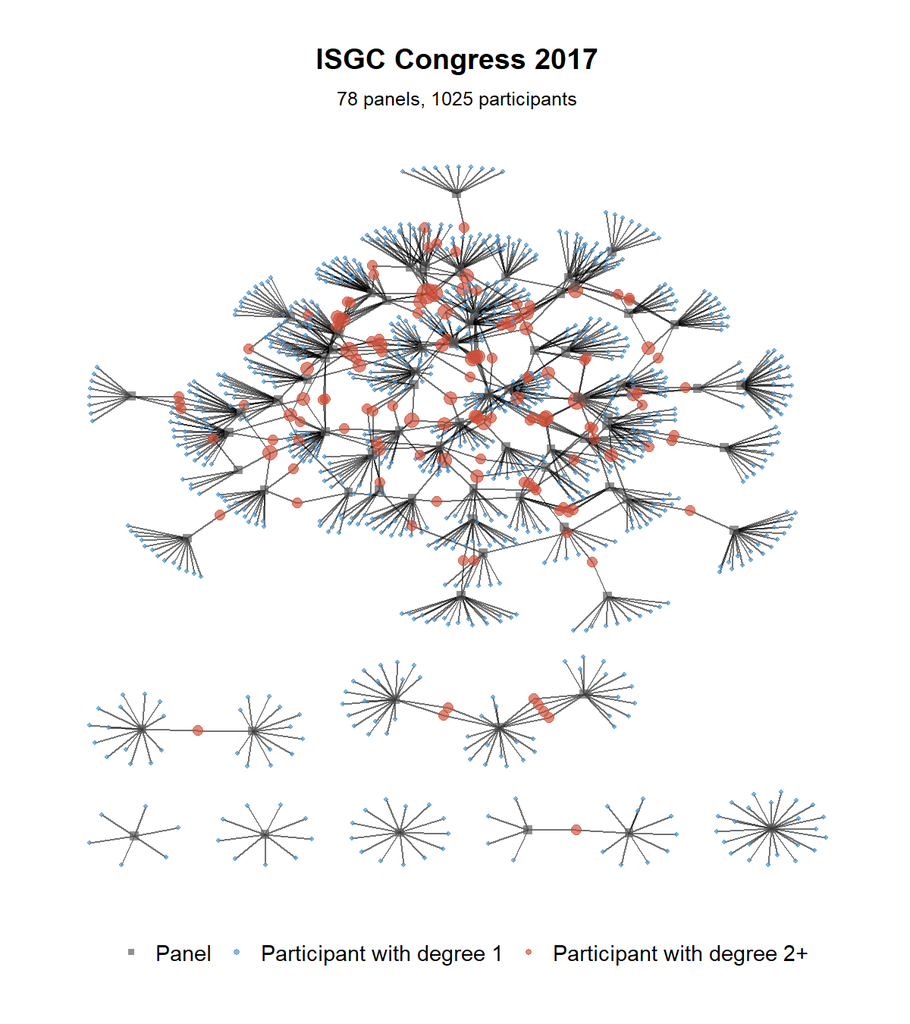

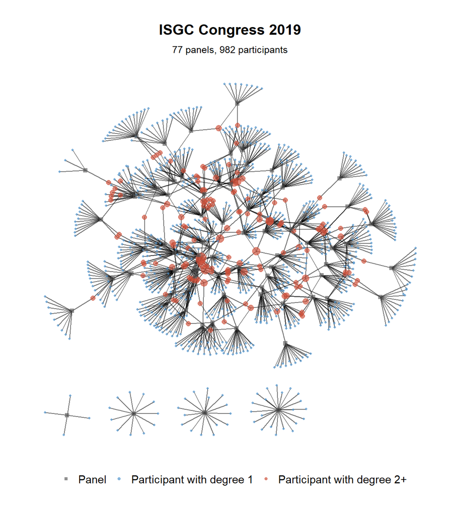

| ISGC Congress | Panels | Participants | Ratio | % degree 1 | % degree 2+ | C - 1 |
| --- | --- | --- | --- | --- | --- | --- |
| 2015 | 64 | 875 | 13.7 | 89.3 | 10.7 | 8 |
| 2017 | 78 | 1025 | 13.1 | 86.8 | 13.2 | 7 |
| 2019 | 77 | 982 | 12.8 | 85.2 | 14.8 | 4 |

In the table above, the “Ratio” column gives the ratio of participants to panels, which drops very slightly over time. It is difficult to draw a conclusion on the fragmentation of the conference as the number of panels at the ISGC is the result of the organisers’ choices when setting up the programme and not of the participants. Indeed, the participants of the ISGC congress choose to associate their paper with a main topic and it is on this basis that the papers are then grouped into panels.

The number of isolated components of the graph, noted as “C - 1” above because only components not connected to the main component have been counted, corresponds to the number of panels in which no participant took part in any other panel of the Congress. This figure is decreasing over time, from 8 in 2015 to 4 in 2019, i.e. a drop of 50%.

In the one-mode networks below, the blue dots indicate participants who attended only one panel of the Congress edition concerned; the red dots indicate participants who attended several panels.

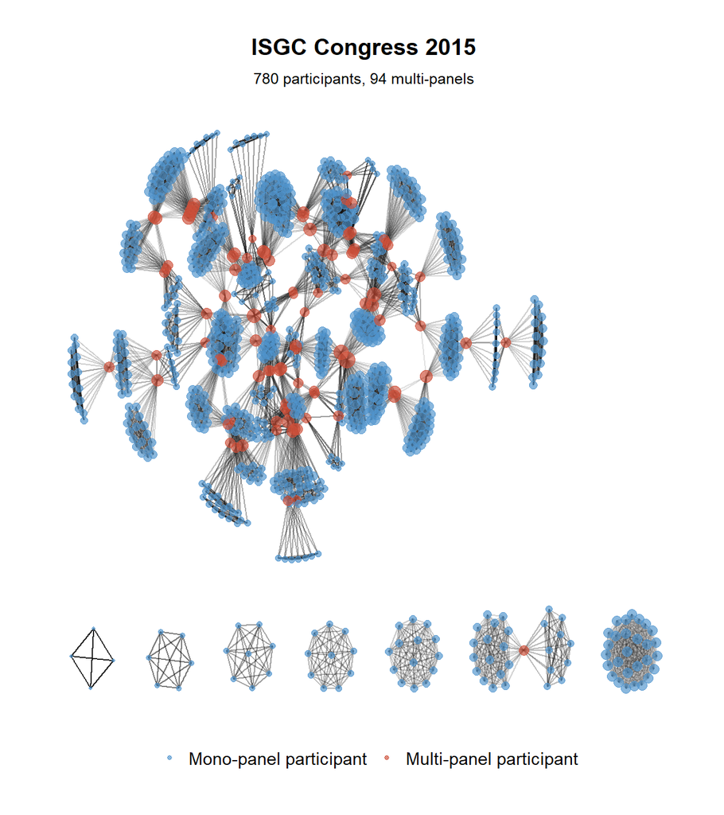

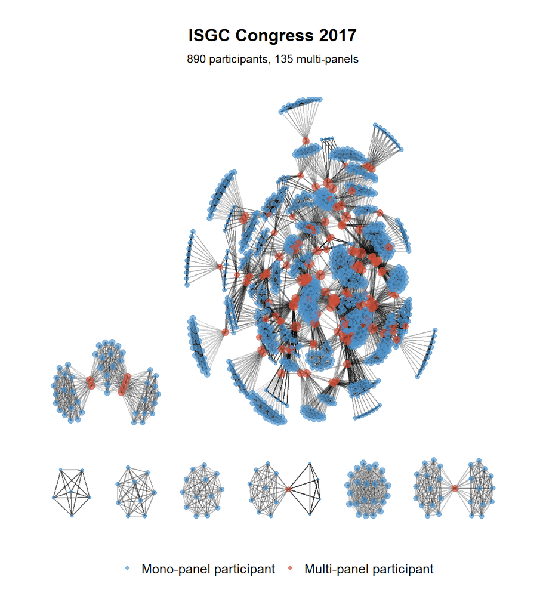

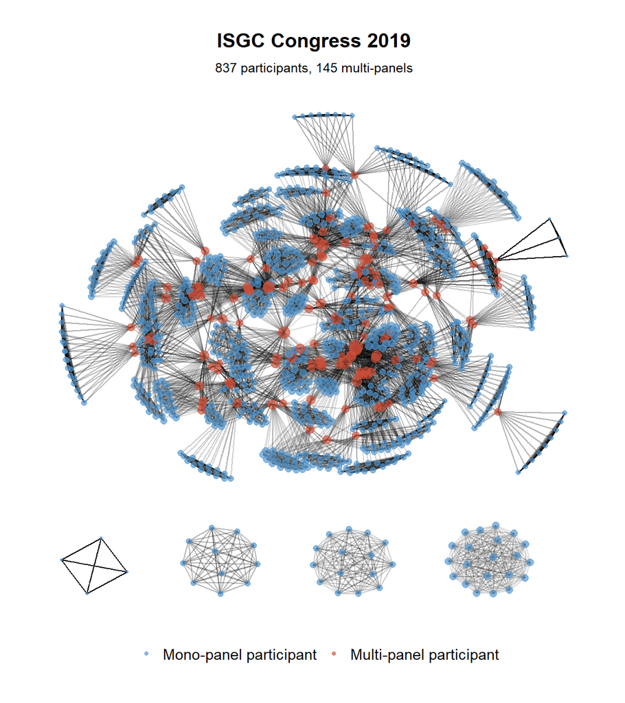

## Linking communications according to common authors and topics

We now consider the network of oral and flash communications sharing one author at least.

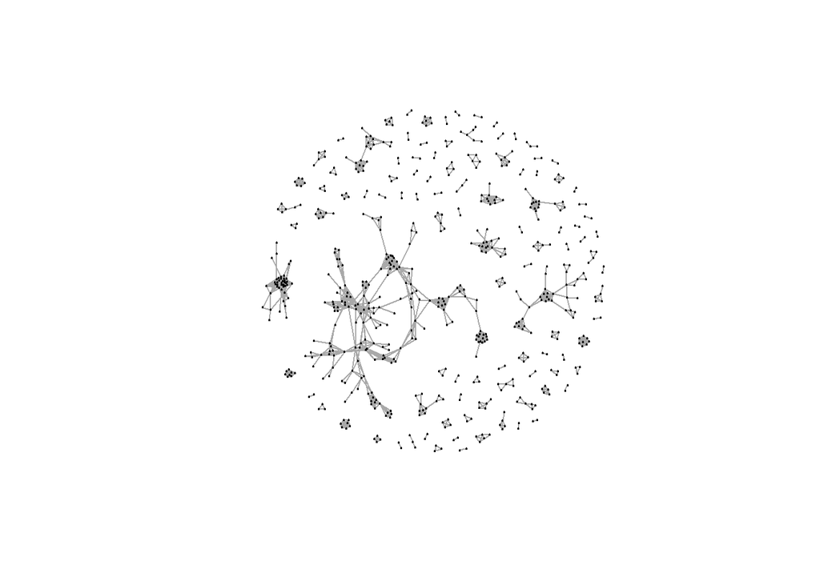

It counts 643 communications, among which 171 from the 2015 edition, 241 from the 2017 edition, and 231 from the 2019 edition.

There are 605 communications with different topics but at least one common authors. We here consider the original topics’ name before the recoding suggested by François Jérôme’s expertise. We group all the communications according to their topic and attempt to visualise the relations between topics.

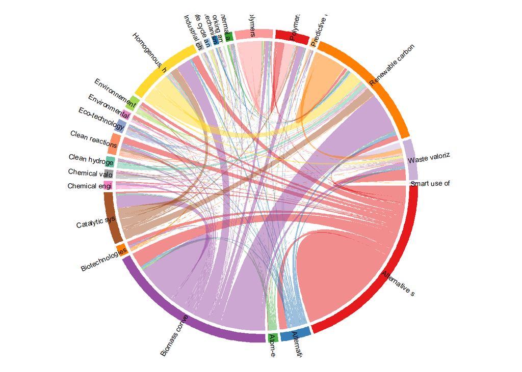

The chord diagram with 25 different topics is not easy to read but it confirms the important link between Biomass conservation and Renawable Carbon that we grouped together in the 16 categories topic variable.

Since certain original topics were only present in certain editions we attempt to visualise the relations between topics using an historical layout. This network is derived from the network of communications having at least one common author.

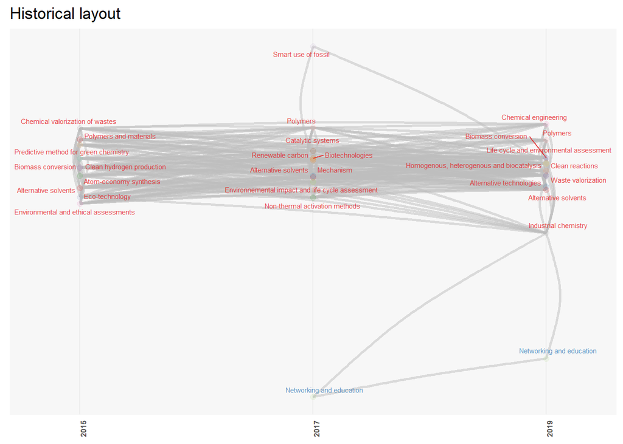

Let now consider the network of relations between ISGC topics using the list of topics recoded into 16 categories.

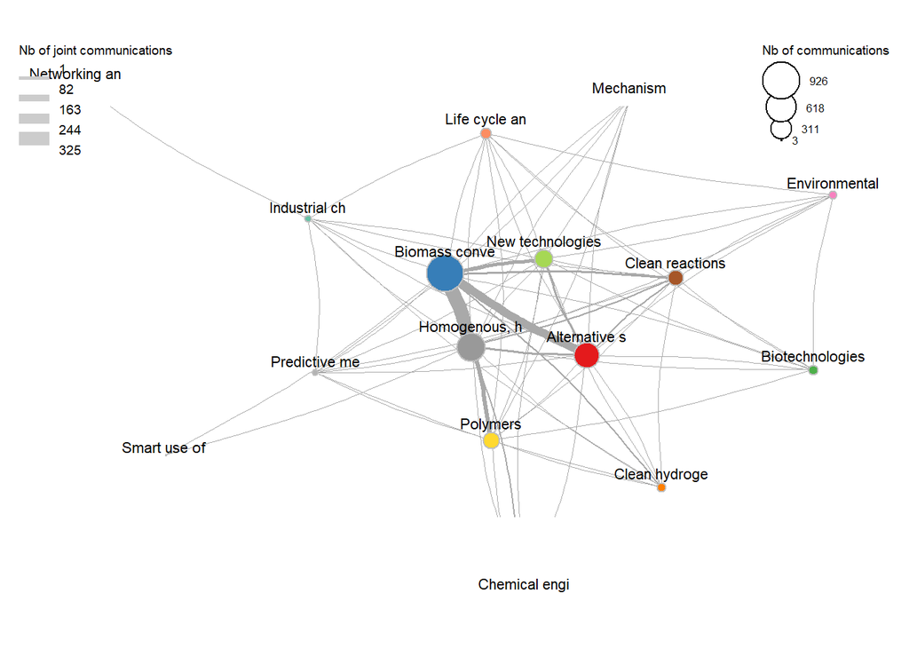

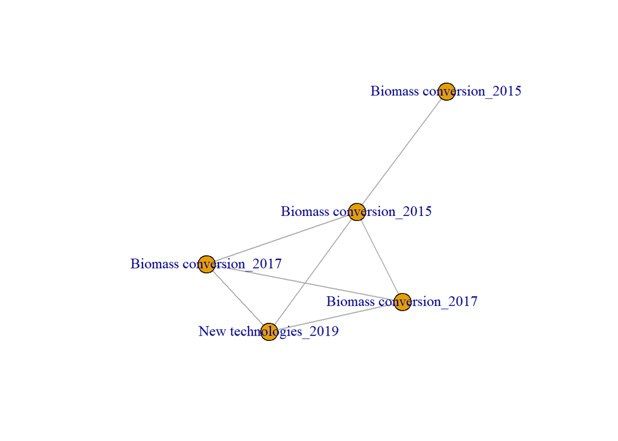